# Explaining image classification with LIME

```r
library(keras)
library(lime)
library(magick)
```

## Input images

Here are 4 images for you to play with.

```r
# By mattbuck (category) - Own work by mattbuck., CC BY-SA 3.0, https://commons.wikimedia.org/w/index.php?curid=20151244
img_path <- "images/Bristol_Balloon_Fiesta_2009_MMB_06.png"

# By GT1976 - Own work, CC BY-SA 4.0, https://commons.wikimedia.org/w/index.php?curid=70893756
# img_path <- "images/wachauer_radtage.png"

# By Thomas Bresson - Own work, CC BY 4.0, https://commons.wikimedia.org/w/index.php?curid=47191548
#img_path <- "images/2016-02-23_16-01-09_paris.png"

# Isiwal/Wikimedia Commons/CC BY-SA 4.0 [CC BY-SA 4.0  (https://creativecommons.org/licenses/by-sa/4.0)], from Wikimedia Commons
# img_path <- "images/21160528_Lofer_Khne_Yan-Lorenz-5943.png"
```

## Model

We will use VGG16 here:

```r
model <- application_vgg16()
```

```
2018-11-23 16:49:40.381338: I tensorflow/core/platform/cpu_feature_guard.cc:141] Your CPU supports instructions that this TensorFlow binary was not compiled to use: AVX2 FMA
```

## Explain prediction using LIME

### Create an explainer

First, you will need to create an `explainer` (a closure) using the `lime` factory function. In the case of images, you will have to pass in

- a path to an image file,
- a reference to the model to be used for prediction
- a function to be used for preprocessing

#### Create a pre-processing function for LIME to use

The pre-processing function should be able to work with a list of paths.

```r
image_prep <- function(x) {
  arrays <- lapply(x, function(path) {
    img <- image_load(path, target_size = c(224,224)) %>%
      image_to_array()
    img <- img %>%
      array_reshape(c(1, dim(img))) %>%
      imagenet_preprocess_input()
  })
  do.call(abind::abind, c(arrays, list(along = 1)))
}
```

##### Explainer

Now create the explainer. You should wrap the model into `as classifier`, passing the target labels to that function. Note that this wrapper is not optional - LIME needs it to be informed about the model type.

```r
model_labels <- readRDS(system.file('extdata', 'imagenet_labels.rds', package = 'lime'))
explainer <- lime(img_path, as_classifier(model, model_labels), image_prep)
```

##### Get a prediction

Before we look at explanations, let’s get a prediction. This is also a good way to test the preprocessing function.

```r
preds <- predict(model, image_prep(img_path))
```

Which is the most probable class?

```r
preds %>% imagenet_decode_predictions()
```

| class_name | class_description | score |
| --- | --- | --- |
| n02782093 | balloon | 9.999468e-01 |
| n03888257 | parachute | 3.710747e-05 |
| n02692877 | airship | 1.597532e-05 |
| n04562935 | water_tower | 4.031161e-08 |
| n04507155 | umbrella | 2.227416e-08 |

```
NA
```

#### Superpixels

LIME determines essential image areas by successively masking homogeneous regions - the so-called superpixels. Explanation results will depend on adequacy of superpixel segmentation used.

[figure not shown]

```r
plot_superpixels(img_path, colour = "cyan", n_superpixels = 50, weight = 10)
```

[figure not shown]

```r
plot_superpixels(img_path, colour = "cyan", n_superpixels = 50, weight = 2)
```

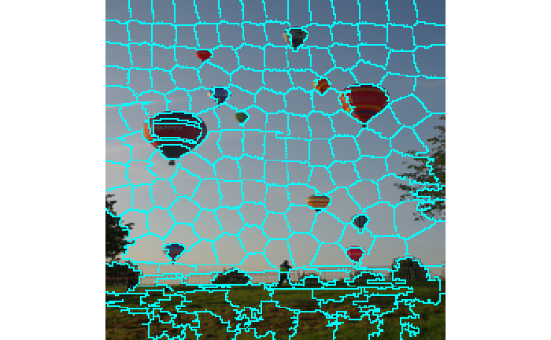

```r
plot_superpixels(img_path, colour = "cyan", n_superpixels = 200, weight = 10)
```

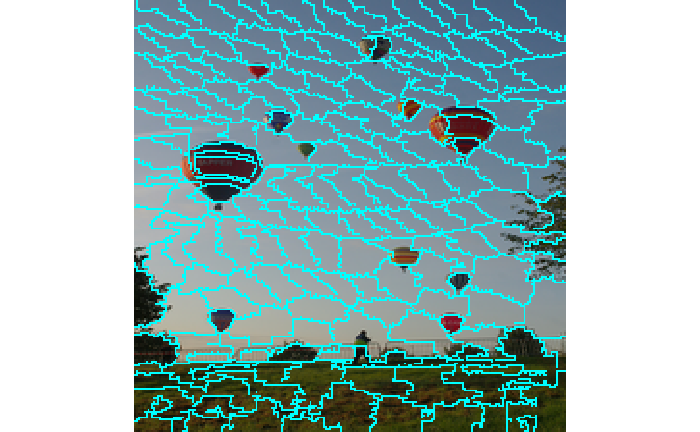

```r
plot_superpixels(img_path, colour = "cyan", n_superpixels = 200, weight = 2)
```

##### Explanation

Now use `explain` to find out what LIME has to say about the why of the model’s “decision”.

```r
explanation <- explain(
  img_path,
  explainer,
  n_labels = 1,
  n_features = 200,
  n_superpixels = 200,
  weight = 10,
  n_permutations = 1000,
  feature_select = "lasso_path")
```

Plot the explanation. Note too that you can view regions that contradict the model’s findings.

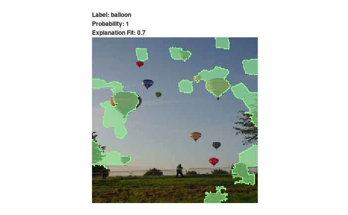

```r
plot_image_explanation(explanation, fill_alpha = 0.6)
```

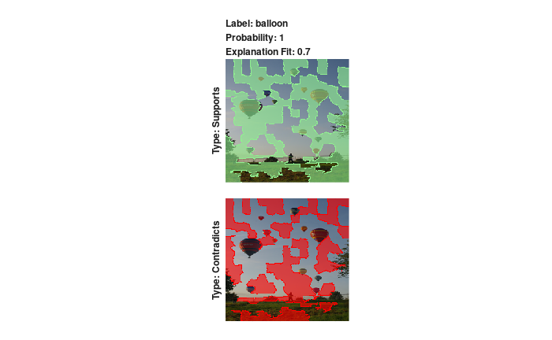

```r
plot_image_explanation(explanation, threshold = 0, show_negative = TRUE, fill_alpha = 0.6)
```

[figure not shown]

```r
plot_image_explanation(explanation, display = "block", block_col = "violet")
```